[figure not shown]

# Makroökonomik II

Winter Semester 2021/2022

by Markus Mößler

# VGR: Entstehung, Verwendung und Veteilung

*Dieses Dokument enthält eine Auswertung der VGR Daten von der OECD.*

## Vorbereitung

Wir verwenden die vierteljährlichen VGR Daten von der Organisation für wirtschaftliche Zusammenarbeit und Entwicklung (OECD).

Die Daten können über das R-Paket `oecd` direkt in die Software R geladen werden.

- R-Paket `oecd`, [Link](https://cran.r-project.org/web/packages/OECD/index.html): Search and extract data from the OECD
- Heruntergelden werden R-Pakete mit: `install.packages(OECD)`.
- Geladen werden R-Pakete mit: `library(OECD)`.

Für die Auswertung verwenden wir vorwiegend *R*-Pakete die in der *base environment* enthalten sind.

Außerde verwenden wir außerdem folgenden R-Pakete:

- `ggplot2`, [Link](https://cran.r-project.org/web/packages/ggplot2/index.html): Create elegant data visualisations using the grammar of graphics
- `dplyr`, [Link](https://cran.r-project.org/web/packages/dplyr/index.html): A grammar of data manipulation
- `tidyr`, [Link](https://cran.r-project.org/web/packages/tidyr/index.html): Tidy messy data
- `lubridate`, [Link](https://cran.r-project.org/web/packages/lubridate/index.html): Make dealing with dates a little easier
- `scales`, [Link](https://cran.r-project.org/web/packages/scales/index.html): Scale functions for visualization
- `zoo`, [Link](https://cran.r-project.org/web/packages/zoo/index.html): S3 Infrastructure for Regular and Irregular Time Series (Z’s Ordered Observations)

Hinweis: Eine benutzerfreundlichere Implementierung würde noch mehr auf die Pakete `dplyr`, `tidyr` nutzen.

Die folgenden *R*-Pakete werden für die Darstellung der Ergebnisse verwendet:

- `gridExtra`, [Link](https://cran.r-project.org/web/packages/gridExtra/index.html): Miscellaneous functions for “grid” graphics
- `kableExtra`, [Link](https://cran.r-project.org/web/packages/kableExtra/index.html): Construct complex table with ‘kable’ and pipe syntax

Überblick

Beispiel: Land Deutschland, 2018

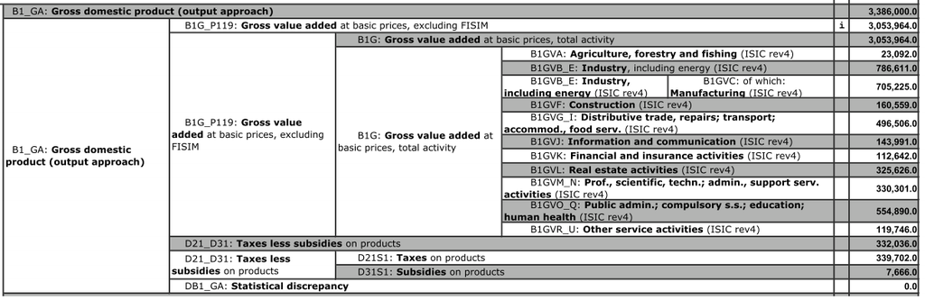

Überblick

Beispiel: Land Deutschland, 2018

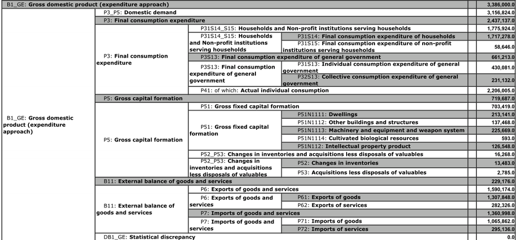

Die Struktur der VGR Daten der OECD kann duch die Funktion `get_data_structure` heruntergalden werden.

Die Daten können duch die Funktion `get_dataset` heruntergalden werden.

## Entstehung

### Deutschland

```
##   LOCATION obsTime    B1_GA  B1GVA  B1GVB_E   B1GVF  B1GVG_I   B1GVJ   B1GVK   B1GVL B1GVM_N  B1GVO_Q B1GVR_U D21_D31    agr      ind     con      ser     tls      tot   agr_X00  ind_X00  con_X00  ser_X00  tls_X00 tot_X00   agr_G01   ind_G01    con_G01   ser_G01   tls_G01   tot_G01     agr_GX01  …
## 1      DEU 2005-Q1 648983.0 4634.0 142682.8 29007.3  94542.8 18360.2 31224.2 64383.9 66119.4 108603.1 27401.3 65991.4 4634.0 142682.8 29007.3 410634.9 65991.4 648983.0 0.7140403 21.98560 4.469655 63.27360 10.16843     100        NA        NA         NA        NA        NA        NA           NA  …
## 2      DEU 2005-Q2 652387.6 4596.2 143413.1 29282.1  94758.0 18993.6 30801.8 64915.1 66817.5 108370.2 27414.8 66850.6 4596.2 143413.1 29282.1 412071.0 66850.6 652387.6 0.7045198 21.98281 4.488451 63.16352 10.24707     100 -0.815710 0.5118346  0.9473477 0.3497267  1.301988 0.5246054 -0.005824498 0…
## 3      DEU 2005-Q3 657986.2 4535.1 144682.4 29500.7  95489.5 19063.0 30723.9 65199.4 67592.3 108872.8 27487.9 68835.1 4535.1 144682.4 29500.7 414428.8 68835.1 657986.2 0.6892394 21.98867 4.483483 62.98442 10.46148     100 -1.329359 0.8850656  0.7465312 0.5721829  2.968560 0.8581708 -0.009365598 0…
## 4      DEU 2005-Q4 661088.1 4443.4 147029.7 28963.6  96393.2 19308.8 30271.5 65558.6 68558.9 109167.0 27707.0 67360.0 4443.4 147029.7 28963.6 416965.0 67360.0 661088.1 0.6721343 22.24056 4.381201 63.07253 10.18926     100 -2.022006 1.6223812 -1.8206348 0.6119748 -2.142947 0.4714233 -0.013936462 0…
## 5      DEU 2006-Q1 667481.1 4358.6 149720.3 27670.0 100777.3 20034.4 30097.8 65760.6 66633.4 108799.2 28023.4 68489.7 4358.6 149720.3 27670.0 420126.1 68489.7 667481.1 0.6529923 22.43064 4.145436 62.94202 10.26092     100 -1.908448 1.8299704 -4.4662956 0.7581212  1.677108 0.9670421 -0.012827337 0…
## 6      DEU 2006-Q2 678980.3 4292.8 153249.9 29228.2 102670.8 20661.5 29936.0 66538.8 68474.5 109350.9 28110.0 69432.1 4292.8 153249.9 29228.2 425742.5 69432.1 678980.3 0.6322422 22.57060 4.304720 62.70322 10.22594     100 -1.509659 2.3574625  5.6313697 1.3368367  1.375973 1.7227754 -0.009857957 0…
```

[figure not shown]

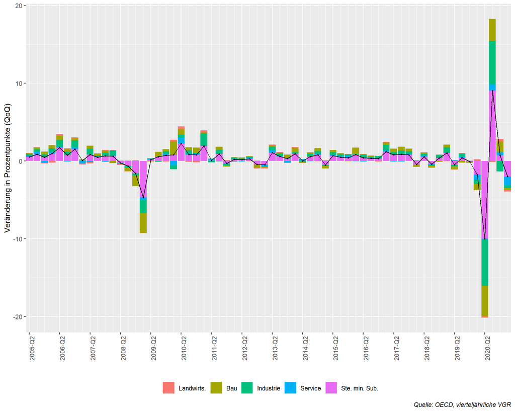

## Verwendung

### Deutschland

```
##   LOCATION obsTime    B1_GE     B11       P3       P5      con      inv     ext      tot  con_X00  inv_X00  ext_X00 tot_X00     con_G01  inv_G01    ext_G01   tot_G01    con_GX01  inv_GX01   ext_GX01  tot_GX01
## 1      DEU 2005-Q1 648983.0 36529.4 489098.9 122394.2 489098.9 122394.2 36529.4 648983.0 75.36390 18.85938 5.628714     100          NA       NA         NA        NA          NA        NA         NA        NA
## 2      DEU 2005-Q2 652387.6 31181.5 490473.3 130312.8 490473.3 130312.8 31181.5 652387.6 75.18127 19.97475 4.779597     100  0.28100656 6.469751 -14.639989 0.5246054  0.21177750 1.2201552 -0.8240432 0.5246054
## 3      DEU 2005-Q3 657986.2 35607.9 490088.5 131672.4 490088.5 131672.4 35607.9 657986.2 74.48310 20.01142 5.411648     100 -0.07845483 1.043336  14.195597 0.8581708 -0.05898334 0.2084037  0.6784924 0.8581708
## 4      DEU 2005-Q4 661088.1 31548.6 491572.7 137663.6 491572.7 137663.6 31548.6 661088.1 74.35812 20.82379 4.772223     100  0.30284326 4.550080 -11.399998 0.4714233  0.22556704 0.9105358 -0.6169278 0.4714233
## 5      DEU 2006-Q1 667481.1 33875.6 493991.4 139381.3 493991.4 139381.3 33875.6 667481.1 74.00830 20.88168 5.075140     100  0.49203302 1.247752   7.375922 0.9670421  0.36586652 0.2598292  0.3519954 0.9670421
## 6      DEU 2006-Q2 678980.3 38057.8 495255.8 145292.7 495255.8 145292.7 38057.8 678980.3 72.94111 21.39866 5.605141     100  0.25595587 4.241172  12.345759 1.7227754  0.18942858 0.8856281  0.6265646 1.7227754
```

[figure not shown]

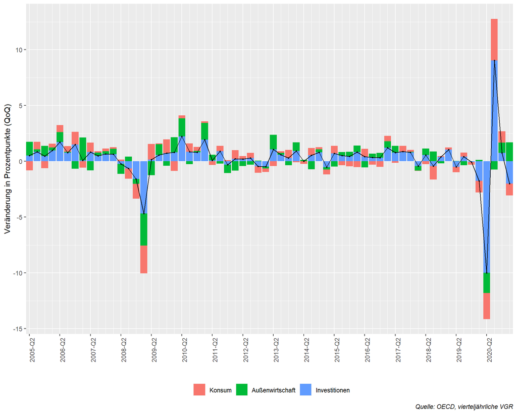